# Walk_On_Sphere_Experiment_Notebook_v2

## Walk-On-Sphere Experiment Notebook by Barry Daemi MATH 6395 Southern Methodist University October 26, 2022 $$\newcommand{\C}{\mathbb{C}} \newcommand{\R}{\mathbb{R}} \newcommand{\Z}{\mathbb{Z}} \newcommand{\Q}{\mathbb{Q}} \newcommand{\P}{\mathbb{P}} \newcommand{\F}{\mathbb{F}} \newcommand{\N}{\mathbb{N}} \newcommand{\E}{\mathbb{E}}$$

This first part of the Jupyter, we will address the physical and theoretical underpinnings of Yan et al. (2013) [0], then in the second part we will implement our own Walk-on-Sphere (WoS) algorithm to solve a two-dimensional Laplace equation with an unit sphere domain, $D$ , and simple boundary, $\partial D$, and a three-dimensional Laplace equation with unit sphere domain$D$, and simple boundary, $\partial D$.  
The objective of Yan et al. (2013) was to proposed a hybrid approach that could approximate solutions to three-dimensional Poisson and modified Helmholtz equations at a reduced computational cost compared to conventional methods found in Boundary Elements Methods (BEMs) and Finite Element Methods (FEMs). The approach combines a locally deterministic Boundary Integral Method with a Feynman-Kac formulated solutions to elliptic Partial Differential Equations (PDEs).  
Further elaborating the authors choice a electrostatic potential problem specific to Very Large Scale Integration (VLSI) chips to implement their hybrid approach; specifically, the domain of electrostatic potential problem is the conductor, $\Omega$, and the boundary condition, $\partial \Omega$, is the surface of the conductor. The surface charge distribution $\sigma_{s}$ from Gauss's Law is equal to the normal derivative of the electrostatic potential,

$$\sigma_{s}=E \cdot n |_{\partial \Omega} = \frac{\partial u}{\partial n} |_{\partial \Omega}.$$

And since the inhomogeneous right-hand side of a Poisson, the authors were able to reduce this Poisson equation through a simple subtraction technique to a Laplace equation with a modified boundary condition. To attain the Dirichlet data one only need to approximate the solution of the Boundary Integral equation over the modified boundary condition, $\partial D$. This can be accomplished through approximating the following form,

$$u(x)=\int_{\partial \Omega} G(x,y)\frac{\partial u(y)}{\partial n_{y}} ds_{y} - \int_{\partial \Omega} \frac{\partial G(x,y)}{\partial n_{y}} u(y) ds_{y} (eq. 2.3) ,$$

simply the $n_{y}$ is the normal derivative of the boundary of $\Omega$ or $\Omega^{c}$ to which any $x \in \Omega$ or $\Omega^{c}$, and where said Green function $G(x,y)$ is the core to the approximate solution of the aforementationed Laplace equation; illustratively,

$$G(x,y)=\frac{1}{4 \pi}\frac{1}{\vert x - y \vert}.$$

To attain the solutions of Laplace equation over the modified boundary, the authors utilized a WoS algorithm; an comparable application of the WoS algorithm could be found in Simonov (2017) [[1](https://www.sciencedirect.com/science/article/pii/S0893965916302816)] and Simonov (2008) [[2](https://link.springer.com/chapter/10.1007/978-3-540-74496-2_38#Bib1_38)]. But if the reader desires to attain an deeper understanding of the WoS algorithm, we would suggest they read Sawhney and Crane (2020)[[3](http://www.cs.cmu.edu/~kmcrane/Projects/MonteCarloGeometryProcessing/index.html), [4](http://www.cs.cmu.edu/~kmcrane/Projects/MonteCarloGeometryProcessing/paper.pdf)], as a framework code written in compiled language C++ could be found on for solving a a two-dimensional Laplace equation [[5](http://www.cs.cmu.edu/~kmcrane/Projects/MonteCarloGeometryProcessing/WoSLaplace2D.cpp.html)].  
Digressing, in Yan et al. (2013, pg. B871-B873) [0], the authors outline the theoretical framework, and the practical implementation of a WoS algorithm posed to solve a Laplace equation. Most importantly the authors expounded with brevity, the role of Feynmann-Kac formula's [[6](https://scholar.harvard.edu/files/forrestgflesher/files/final_paper_final.pdf)] abridgement of stochastic processes and partial differential equations; in essence the through the Feynman-Kac formula the solution to the Laplace equation with modified boundary conditions is given by,

$$u(x)=E^{x}\big(\phi(X_{\tau_{\Omega}})\big)+E^{x}\bigg[ \int_{0}^{\tau_{\Omega}} f(X_{t}) dt \bigg],$$

which means that the solution is given by the expected value of the collection of Brownian motion paths that hit the modified boundary, $\partial \Omega$; given when the forcing function $f \equiv 0$. Consequentially, the previous formula becomes,

$$u(x)=E^{x}\big(\phi(X_{\tau_{\Omega}})\big)= \int_{\partial \Omega} \phi(y) d \mu_{\Omega}^{x}.$$

And simply the $\phi(y)$ is the point where a said Brownian motion path hits the boundary $\partial \Omega$, and $\mu_{\Omega}^{x}$ the respective probability that that event occurring.  
Subsequentially the authors proceeded to the attainment of the Neumann data that is required in this Hybrid approach, Yan et al. (2013,pg. 876-877); the authors applied eq. 2.3 over the arbitrary superimposed hemisphere, $\Omega_{S}$, on the boundary condition, $\partial \Omega$, of the space $\Omega$; it yielded

$$u(x)=-\int_{\Gamma} \frac{\partial G(x,y)}{\partial n_{y}} u(y) ds_{y}+\int_{S} \bigg[ \frac{\partial G(x,y)}{\partial n_{y}} u(y)+G(x,y)\frac{\partial u(y)}{\partial n_{y}} \bigg] ds_{y}, x \in \Omega_{S} (eq. 4.1).$$

Consequentially by solving eq. 4.1 for $u(x)$, we can attain the Neumann data over the domain $S$, which is what was being sought in this process. And similarly to attaining the Dirichlet data, the authors of Yan et al. (2013) suggested to the reader that they should consider utilizing a WoS algorithm to solve eq 4.1. In essence one needs to form said linear algebraic system,

$$K\bigg[ \frac{\partial u}{\partial n} \bigg](x) = b(x), x \in S,$$

where,

$$K\bigg[ \frac{\partial u}{\partial n} \bigg]=\int_{S} G(x,y)\frac{\partial u(y)}{\partial n_{y}}ds_{y},$$

and,

$$b(x)=\bigg[ \frac{u(x)}{2}+\int_{S} \frac{\partial G(x,y)}{\partial n_{y}} u(y)ds_{y}\bigg]+\int_{\Gamma} \frac{\partial G(x,y)}{\partial n_{y}} u(y)ds_{y}.$$

Then form the well-condition form of said system found in eq. 4.6, eq. 4.7 and eq. 4.8; then solving said well-conditioned system with an iterative solver. In essence this is the entirety of the computational method named Boundary Integral Equation-Walk-on-Sphere (BIE-WoS); in addition, the authors outlined the algorithm in the following description.

> **BIE-WoS Algorithm.**The BIE-WoS method for Neumann data over a patch $S$ consists of the following steps
> - Step 1. Apply the Feynmann-Kac formula (eq. 2.9) using the WoS sampling technique to compute the right-hand-side function $b(x)$ in (eq. 4.4) or (eq. 4.8) by appropriate Gauss quadratures.
> - Step 2. Solve the BIE (eq. 4.2) or (eq. 4.6) with a collocation method to obtain the Neumann data $\frac{\partial u}{\partial n}$ over S.

As aformentationed by the authors, after the Neumann data is attained, the eq. 2.3 from Yan et al. (2013, eq. 2.3, pg. B870) can be used to the electrostatic potential over the whole space.

The first implemention of our WoS algorithm will pertain to a non-mixed BVP of the two-dimension Laplace equation over a unit cirle domain, $D=[-1,1] \times [-1,1]$, with $u(x)=f(x)$ on the boundary, $\partial D$. Our second implementation will pertain to a non-mixed BVP of the three-dimension Laplace equaton over a unit sphere domain, $D=[-1,1] \times [-1,1] \times [-1,1] \equiv [-1,1]^{3}$, with $u(x,y)=f(x,y)$ on the boundary, $\partial D$.  
Let begin we the first implementation; the two-dimension Laplace equation,

$$\bigtriangleup u(x)=0 \text{ for } x \in \R^{2}.$$

The Boundary value problem for Laplace equation is represented as,

$$ \begin{cases} \frac{\partial^{2} u}{\partial x^{2}} + \frac{\partial^{2} u}{\partial y^{2}}=0, & \mbox{ in domain } D\\ u(x)=f(x), & \mbox{ on boundary } \partial D \end{cases}.$$

To illustrate the unit circle domain, we included the following image.

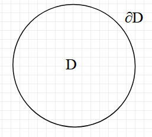

To begin with implementation, we only need to import numpy as `np`, matplotlib.pyplot as `plt`, scipy.stats as `stats` and functions Point and line from sympy. In fact the implementation of a Walk-on-Sphere algorithm does not require many Python packages, and the most technical component of the algorithm is the Brownian motion algorithm contained in the algorithm itself that generates the independent and identically (i.i.d) distributed random normal sphere walk that maps the boundary.  
To generate the Brownian motion paths, we utilized Algoritm 5.17 (Generating Brownian motion) from *Handbook of Monte Carlo Methods* by Dirk P. Kroese, Thomas Taimre and Zdravko I. Botev (2011, pg. 182) [[7](https://people.smp.uq.edu.au/DirkKroese/montecarlohandbook/), [8](https://onlinelibrary.wiley.com/doi/book/10.1002/9781118014967)], and implemented the algorithm in Python. To generate the standard normal random variable denoted in Kroese et al. (2011, pg. 182), $Z_{t}=\big( W_{t}, \ldots, W_{t_{n}}\big)$, we choice to utilize the Box-Muller transform method [[9](https://en.wikipedia.org/wiki/Box%E2%80%93Muller_transform)].  
To test our Python implementation of Algoritm 5.17, we choice time to be 1 second, e.g. `t=1`, with ten-thousand sampled steps.

```python
import numpy as np
import matplotlib.pyplot as plt
import scipy.stats as stats
from sympy import Point, Line
```

```python
n=10000;
U1=np.random.uniform(0,1,n);
U2=np.random.uniform(0,1,n);
X=np.sqrt(-2*np.log(U1))*np.cos(2*np.pi*U2);

t=1; h=np.sqrt(t/n);

DW=h*X;
W=np.zeros(n+1);
W[1:]=np.cumsum(DW);
plt.ylabel("Range of Brownian Motion")
plt.xlabel("Steps");
plt.title("Brownian Motion");
plt.plot(W);
```

[output not shown]

To further illustrate that our implementation of Algorithm 5.17 correct, and to further demonstrate the behavior of Brownian motion, we generated ten Brownian motion paths in a single plot.

```python
for i in range(10):
    n=10000;
    U1=np.random.uniform(0,1,n);
    U2=np.random.uniform(0,1,n);
    X=np.sqrt(-2*np.log(U1))*np.cos(2*np.pi*U2);

    t=1; h=np.sqrt(t/n);

    DW=h*X;
    W=np.zeros(n+1);
    W[1:]=np.cumsum(DW);
    plt.plot(W);

plt.ylabel("Range of Brownian Motion")
plt.xlabel("Steps");
plt.title("Brownian Motion");
plt.show()
```

[output not shown]

As one can observe, one-dimensional Brownian motion is insufficient for an two-dimensioned WoS algorithm, as the direction of motion is limited to forward advancemeant along the horizontal-axis, and therefore does not possess the full-directional versatility of two-dimension Brownian motion.  
To implement two-dimensioned Brownian motion, we only need to generate an additional Brownian motion path in the y-direction to give the desired variation and advancement in the vertical-axis. To generate this additional Brownian motion path, we reused the Box-Muller transformation second transform to generate a second standard normal random variable, which was passed through Algorithm 5.17 to generate the path.

```python
n=10000;
U1=np.random.uniform(0,1,n);
U2=np.random.uniform(0,1,n);
X=np.sqrt(-2*np.log(U1))*np.cos(2*np.pi*U2);
Y=np.sqrt(-2*np.log(U1))*np.sin(2*np.pi*U2);

t=1; h=np.sqrt(t/n);

DW1=h*X;
W1=np.zeros(n+1);
W1[1:]=np.cumsum(DW1);

DW2=h*Y;
W2=np.zeros(n+1);
W2[1:]=np.cumsum(DW2);

plt.ylabel("Range of Brownian Motion")
plt.xlabel("Steps");
plt.title("Brownian Motion");
plt.plot(W1,W2);
```

[output not shown]

```python
n=10000;
U1=np.random.uniform(0,1,n);
U2=np.random.uniform(0,1,n);
X=np.sqrt(-2*np.log(U1))*np.cos(2*np.pi*U2);
Y=np.sqrt(-2*np.log(U1))*np.sin(2*np.pi*U2);

t=1; h=np.sqrt(t/n);
times=np.linspace(0,1,n+1);

DW1=h*X;
W1=np.zeros(n+1);
W1[1:]=np.cumsum(DW1);

DW2=h*Y;
W2=np.zeros(n+1);
W2[1:]=np.cumsum(DW2);

fig=plt.figure();
ax=plt.axes(projection='3d');
zline=times;
xline=W1;
yline=W2;
ax.plot3D(xline, yline, zline, 'gray');
fig.set_size_inches(12.5, 8.5)
ax.set_xlabel('Range of Brownian Motion in X');
ax.set_ylabel('Range of Brownian Motion in Y');
ax.set_zlabel('Range of Brownian Motion in Z');
```

[output not shown]

```python
n=10000;
U1=np.random.uniform(0,1,n);
U2=np.random.uniform(0,1,n);
X=np.sqrt(-2*np.log(U1))*np.cos(2*np.pi*U2);
Y=np.sqrt(-2*np.log(U1))*np.sin(2*np.pi*U2);
U3=np.random.uniform(0,1,n);
U4=np.random.uniform(0,1,n);
Z=np.sqrt(-2*np.log(U1))*np.cos(2*np.pi*U2);


t=1; h=np.sqrt(t/n);

DW1=h*X;
W1=np.zeros(n+1);
W1[1:]=np.cumsum(DW1);

DW2=h*Y;
W2=np.zeros(n+1);
W2[1:]=np.cumsum(DW2);

DW3=h*Z;
W3=np.zeros(n+1);
W3[1:]=np.cumsum(DW3);

fig=plt.figure();
ax=plt.axes(projection='3d');
zline=W1;
xline=W2;
yline=W3;
ax.plot3D(xline, yline, zline, 'gray');
fig.set_size_inches(12.5, 8.5)
ax.set_xlabel('Range of Brownian Motion in X');
ax.set_ylabel('Range of Brownian Motion in Y');
ax.set_zlabel('Range of Brownian Motion in Z');
```

[output not shown]

Yet again, we desire to illustrate the correctness of our implementation, and further demonstrate the behavior of three-dimensional Brownian motion.

```python
for i in range(3):
    n=10000;
    U1=np.random.uniform(0,1,n);
    U2=np.random.uniform(0,1,n);
    X=np.sqrt(-2*np.log(U1))*np.cos(2*np.pi*U2);
    Y=np.sqrt(-2*np.log(U1))*np.sin(2*np.pi*U2);
    U3=np.random.uniform(0,1,n);
    U4=np.random.uniform(0,1,n);
    Z=np.sqrt(-2*np.log(U1))*np.cos(2*np.pi*U2);


    t=1; h=np.sqrt(t/n);

    DW1=h*X;
    W1=np.zeros(n+1);
    W1[1:]=np.cumsum(DW1);

    DW2=h*Y;
    W2=np.zeros(n+1);
    W2[1:]=np.cumsum(DW2);

    DW3=h*Z;
    W3=np.zeros(n+1);
    W3[1:]=np.cumsum(DW3);

    fig=plt.figure();
    ax=plt.axes(projection='3d');
    zline=W1;
    xline=W2;
    yline=W3;
    ax.plot3D(xline, yline, zline, 'gray');
    fig.set_size_inches(12.5, 8.5)
    ax.set_xlabel('Range of Brownian Motion in X');
    ax.set_ylabel('Range of Brownian Motion in Y');
    ax.set_zlabel('Range of Brownian Motion in Z');
```

[output not shown]

Central to our focus, we can finally implement our WoS algorithm. Though to experiment, we will first implement a random walk algorithm, so to compared its result's with the WoS algorithm's.  
Our random walk algorithm is composed of two Python functions, `simulate_exit_time(w,n,t)` and `check_exit`; the first function is the core of the algorithm where the Brownian motion is generated, the second function is the termination function, when the Brownian motion hits the boundary condition.  
The following implementation is in regards to a unit sphere domain, $D$, which has a simple boundary, $\partial D$.

```python
def check_exit(w):
    if np.linalg.norm(w) >=1:
        return True;
    return False;

def simulate_exit_time(w,n,t):
    h=np.sqrt(t/n);
    exit=False;
    x=w.copy();
    i=0; temp=0;
    while not exit:
        U1=np.random.uniform(0,1,2);
        U2=np.random.uniform(0,1,2);
        y=np.sqrt(-2*np.log(U1))*np.cos(2*np.pi*U2);
        x=x+h*y
        exit=check_exit(x);
        if exit==False:
            r=1-np.linalg.norm(x);
            circle1=plt.Circle(x,radius=r,fill=False);
            plt.gcf().gca().add_artist(circle1);
            plt.axis([-1.2, 1.2, -1.2, 1.2]);
        if np.linalg.norm(temp)!=0:
            x_val=[temp[0],x[0]]; y_val=[temp[1],x[1]];
            plt.plot(x_val,y_val);
        plt.text(x[0],x[1],'x'+str(i+1));
        i=i+1;
        temp=x;
    return x;
```

Though the position is initialize at `w=np.array((0,0))`, the actual initialization point is set from the first Brownian motion sample. Similar to the our previous implementation of two-dimensional Brownian motion, we set time to one second, `t=1`; though for this experiment we set the partition number to eight, `n=8`, so that the resulting plot could remain legible.

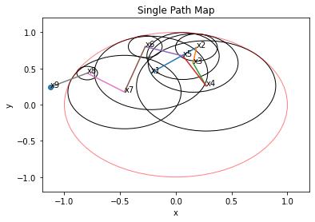

```python
w=np.array((0,0)); t=1; n=8;
exit_times=np.array([simulate_exit_time(w,n,t) for k in range(0,1)]);


circle1=plt.Circle((0,0),1,color='r', fill=False, alpha=.5);
plt.gcf().gca().add_artist(circle1);
plt.axis([-1.2, 1.2, -1.2, 1.2]);
plt.scatter(exit_times[:,0],exit_times[:,1]);
plt.title("Single Path Map");
plt.xlabel("x");
plt.ylabel("y");
plt.show();
```

Observing the result, one can discern that a random walk algorithm take several steps prior to hitting the boundary condition, $\partial D$. This means there exists a probablistic computational overhead that can vary depending on the optimality of the Brownian motion path that develops. This computational overhead can increase in the worst case scenario, such as, in `Example #2 - Unlucky Case`, or it can remain constant (e.g. the same) in the case of `Example #1 - Lucky Case`.

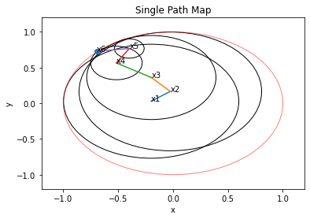

```python
# Example 1 - Increase in time partition from 8 to 32
# Lucky example: Computational overhead remained constant due to Brownian motion pathway
# to the boundary

w=np.array((0,0)); t=1; n=32;
exit_times=np.array([simulate_exit_time(w,n,t) for k in range(0,1)]);


circle1=plt.Circle((0,0),1,color='r', fill=False, alpha=.5);
plt.gcf().gca().add_artist(circle1);
plt.axis([-1.2, 1.2, -1.2, 1.2]);
plt.scatter(exit_times[:,0],exit_times[:,1]);
plt.title("Single Path Map");
plt.xlabel("x");
plt.ylabel("y");
plt.show();
```

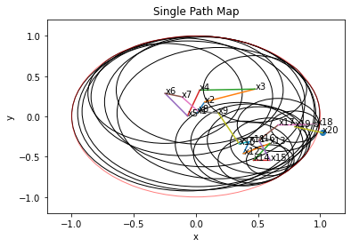

```python
# Example 2 - Increase in time partition from 8 to 32
# Unlucky example: Computational overhead increased due to Brownian motion pathway to the boundary

w=np.array((0,0)); t=1; n=32;
exit_times=np.array([simulate_exit_time(w,n,t) for k in range(0,1)]);


circle1=plt.Circle((0,0),1,color='r', fill=False, alpha=.5);
plt.gcf().gca().add_artist(circle1);
plt.axis([-1.2, 1.2, -1.2, 1.2]);
plt.scatter(exit_times[:,0],exit_times[:,1]);
plt.title("Single Path Map");
plt.xlabel("x");
plt.ylabel("y");
plt.show();
```

To further illustrate this phenomenon, generate another example, but with a finer partition of time, from thirty two to two-hundred, e.g., `n=200`.

```python
def check_exit(w):
    if np.linalg.norm(w) >=1:
        return True;
    return False;

def simulate_exit_time(w,n,t):
    h=np.sqrt(t/n);
    exit=False;
    x=w.copy();
    i=0; temp=0;
    while not exit:
        U1=np.random.uniform(0,1,2);
        U2=np.random.uniform(0,1,2);
        y=np.sqrt(-2*np.log(U1))*np.cos(2*np.pi*U2);
        x=x+h*y
        exit=check_exit(x);
        if np.linalg.norm(temp)!=0:
            x_val=[temp[0],x[0]]; y_val=[temp[1],x[1]];
            plt.plot(x_val,y_val);
        i=i+1;
        temp=x;
    return x;
```

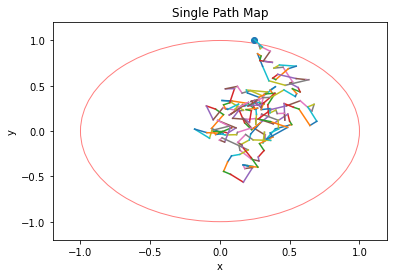

```python
w=np.array((0,0)); t=1; n=200;
exit_times=np.array([simulate_exit_time(w,n,t) for k in range(0,1)]);

circle1=plt.Circle((0,0),1,color='r', fill=False, alpha=.5);
plt.gcf().gca().add_artist(circle1);
plt.axis([-1.2, 1.2, -1.2, 1.2]);
plt.scatter(exit_times[:,0],exit_times[:,1]);
plt.title("Single Path Map");
plt.xlabel("x");
plt.ylabel("y");
plt.show();
```

This is the worst case scenario, where $n > 200$ Brownian motion samples were generated during this single path, which is a enormous computational overhead to accumulate with each additional possible Brownian motion pathway generated. Though I should remind the read that a random walk algorithm is a more naive implementation of the WoS algorithm, and therefore this method does not implement the crucial computational cost saving technique known as sphere walking. With that being stated, the naive random walk still serves computational saving in comparison to a conventional Fintie Elements Method.  
To maintain the plots legibility, we removed the cirle plot, line interpolator and the $x_{i}$ notation which lablled each Brownian motion step. And hence one can observe that the code implementation for this random walk algorithm is minimal, and the technical details of this algorithm is entirely held in the mathematics and not the coding implementation; which is phenomenal fact in of itself.

```python
def check_exit(w):
    if np.linalg.norm(w) >=1:
        return True;
    return False;

def simulate_exit_time(w,n,t):
    h=np.sqrt(t/n);
    exit=False;
    x=w.copy();
    while not exit:
        U1=np.random.uniform(0,1,2);
        U2=np.random.uniform(0,1,2);
        y=np.sqrt(-2*np.log(U1))*np.cos(2*np.pi*U2);
        x=x+h*y
        exit=check_exit(x);
    return x;
```

Proceeding, we will finally simulate our random walk algorithm: we decided upon time scale of one second with two-thousand partitions. With that, we decided to generate ten-thousand Brownian motion pathways. In addition we choice to time, so to compare its computational cost to a WoS algorithm. We accomplished this task with incorporation of `process_time` from the time package, which captures the time it executes, so we were able to capture the CPU process time of our random walk algorithm.  
With a `n=2000` partition of the time scale $t$, we gave these Brownian motion paths a finer time scaled then the previous example; it effect, we introduced a greater variation into the algorithm. In essence a Brownian motion that possesses a finer partition of the time scale, subsequentially possesses a smaller size step, as each Brownian motion sample - aka step size is proportioned with the square root of the time scale's partition size, $\Delta t$, which is the standard deviation of the normal distribution that the Brownian motion step is being drawn (or sampled) from. Recollection, a standard normal random variable, $Z=\mathcal{N}(\mu=0,\sigma^{2}=1)$, can be transformed into another non-standard normal, $X$, given the following transformation,

$$X=\sigma Z+\mu.$$

We can prove this transformation simply,

$$E[X]=E[\sigma Z + \mu]=\sigma E[Z] + \mu= \sigma \cdot 0 + \mu = \mu,$$

and,

$$Var[X]=Var[\sigma Z + \mu] = \sigma^{2} Var[Z] + 0 = \sigma^{2} \cdot 1 = \sigma^{2}.$$

Consequentially each Brownian motion sample, $B_{t}$, is from a normal distribution, $B_{t}=\mathcal{N}(\mu=0,\sigma^{2}=\sqrt{\Delta t})$. With key fact in mind, one can discern that a smaller step size means that the sample of said step originates from a normal with a small variance, which cause the Brownian motion step to be lessed variated. But due to the increase in the number of sampled that can be drawn from $\mathcal{N}(\mu=0,\sigma^{2}=\sqrt{\Delta t})$ with a finer time scale mesh, it variation seems to be greater then a Brownian motion that possesses a less fine time scale mesh. Though this additional variation increases the propensity of the Brownian motion pathways to tend to the worst case scenario, as the smaller step size allows for a greater propensity for a Brownian path to wonder inside the domain, resulting in perhap a needless incease in the computational overhead of the algorithm.  
Though we will discuss this further in a bit. Mean while, let proceed with experimentation, we choice partition of the time scale of `n=2000`, and decide to generate ten-thousand Brownian motion paths.

```python
from time import process_time
```

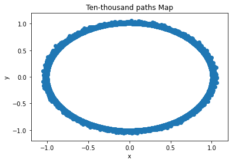

```
Elapsed time:147.265625 seconds
```

```python
t1_start=process_time();
w=np.array((0,0)); t=1; n=2000;
exit_times=np.array([simulate_exit_time(w,n,t) for k in range(0,10000)]);

circle1=plt.Circle((0,0),1,color='r', fill=False, alpha=.5);
plt.gcf().gca().add_artist(circle1);
plt.axis([-1.2, 1.2, -1.2, 1.2]);
plt.scatter(exit_times[:,0],exit_times[:,1]);
plt.title("Ten-thousand paths Map");
plt.xlabel("x");
plt.ylabel("y");
plt.show();
t1_stop=process_time();
time=t1_stop-t1_start
print("Elapsed time: " + str(time) + " seconds");
```

The said experiment took approximately 147 seconds, or two minutes and 27 seconds. It seems that the random walk algorithm possesses a bit of a steep computational cost. Though let see how this algoithm will perform without the explicit mapping of the exit points, e.g., $\phi(y)$. The following experiment will computate the following equation,

$$u(x)=E^{x}\big(\phi(X_{\tau_{\Omega}})\big)= \int_{\partial \Omega} \phi(y) d \mu_{\Omega}^{x},$$

which is the Feynmann-Kac formulated solution to $u(x)$, which is the solution to the two-dimensionoal Laplace equation. In addition we will measure the time elapsed during the execution of the following experiment.

```
The value u(v) = 0.5000000000000001
The value of Exp(f(Exit))=0.5149208465226206
Elapsed time: 13.28125 seconds
```

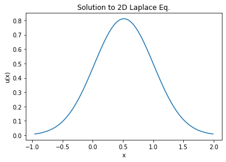

```python
t1_start=process_time();
w=np.array((0.5,0.5)); t=1; n=2000; n_trials=10000;
u=lambda x:np.linalg.norm(x,2)*np.cos(np.arctan2(x[0],x[1]))
f=lambda x:np.cos(np.arctan2(x[0],x[1]));

def get_exp_f_exit(starting, n_trials):
    temp=[f(simulate_exit_time(w,n,t)) for k in range(0,n_trials)];
    mean=np.mean(temp);
    std=np.std(temp);
    return mean,std;

[exp_f_exit,std]=get_exp_f_exit(w,n); # Expected value of f(Exit(x,d))
print('The value u(v) = %s\nThe value of Exp(f(Exit))=%s' %(u(w),exp_f_exit));
t1_stop=process_time();
time=t1_stop-t1_start
print("Elapsed time: " + str(time) + " seconds");

X=np.linspace(exp_f_exit-3*std,exp_f_exit+3*std,100);
plt.plot(X,stats.norm.pdf(X,exp_f_exit,std));
plt.title("Solution to 2D Laplace Eq.");
plt.xlabel("x");
plt.ylabel("u(x)");
plt.show();
```

```python
f=lambda x:np.cos(np.arctan2(x[0],x[1]));

def get_exp_f_exit(starting, n_trials):
    temp=[f(simulate_exit_time(w,n,t)) for k in range(0,n_trials)];
    mean=np.mean(temp);
    std=np.std(temp);
    return mean,std;

N=[20,50,100,1000];
x=np.zeros((5,10));

for i in range(len(N)):
    for j in range(10):
        w=np.array((0.5,0.5)); t=1; n=N[i]; n_trials=10000;
        [exp_f_exit,std]=get_exp_f_exit(w,n);
        x[i,j]=exp_f_exit;
    average=np.mean(x[i,:]);
    print("Pratitions: n=" + str(N[i]));
    print("u(x) for each number of partitions:")
    print(x[i,:])
    print(" ")
    print("Mean: " + str(np.mean(x[i,:])) + "  " + "Standard Deviation: " + str(np.std(x[i,:])));
    print("Confidence Interval: " +
          str(stats.t.interval(alpha=0.95, df=10-1, loc=average, scale=stats.sem(x[i,:]))));
    print(" ")
```

```
Pratitions: n=20
u(x) for each number of partitions:
[0.40647115 0.44000142 0.29859635 0.40050623 0.51718386 0.49435558
 0.25034942 0.21472891 0.37284875 0.43387509]

Mean: 0.38289167765261123  Standard Deviation: 0.09499390313247093
Confidence Interval: (0.3112612981899969, 0.45452205711522553)

Pratitions: n=50
u(x) for each number of partitions:
[0.57149499 0.40879862 0.57998315 0.32672178 0.49969118 0.39126743
 0.45582788 0.53550033 0.41603923 0.4762371 ]

Mean: 0.4661561689563996  Standard Deviation: 0.07813208246102435
Confidence Interval: (0.40724048563004095, 0.5250718522827583)

Pratitions: n=100
u(x) for each number of partitions:
[0.52947677 0.49931448 0.51296631 0.46494773 0.40208996 0.49911548
 0.45662738 0.48859184 0.44214021 0.36995297]

Mean: 0.46652231364204094  Standard Deviation: 0.04787175976811637
Confidence Interval: (0.4304244988912208, 0.5026201283928611)

Pratitions: n=1000
u(x) for each number of partitions:
[0.50730098 0.49151758 0.50948458 0.50964486 0.51866057 0.45689096
 0.49104086 0.47703702 0.47086612 0.45618384]

Mean: 0.48886273570844185  Standard Deviation: 0.0215653879178283
Confidence Interval: (0.4726013034599074, 0.5051241679569763)
```

Despite generating ten-thousand Brownian motion paths, the variation in the estimate parameter is quite large, and therefore the resulting confidence interval is very loose. Though with the increase in the number of partitions of the time scale, one can observe that the variation decreases and the confidence interval tightens; simply the reduction in the variation results in a better estimate.  
For the second experiment, the number of partitions were set to be `n=2000`, which results in a substantially larger computational overhead due to the propensity of the Brownian motion paths to wonder, but this behavior might be of a benefit to a certain extend to the accuracy of the estimated parameter. Nevertheless, we created a nested for loop that iterated over a list that contained, `n`, the number of Brownian motion paths that would be generated during the execution of the algorithm. Yet again, we ran each `n` for ten trails.

```python
f=lambda x:np.cos(np.arctan2(x[0],x[1]));

def get_exp_f_exit(starting, n_trials):
    temp=[f(simulate_exit_time(w,n,t)) for k in range(0,n_trials)];
    mean=np.mean(temp);
    std=np.std(temp);
    return mean,std;

N=[20,50,100,1000];
x=np.zeros((5,10));

for i in range(len(N)):
    for j in range(10):
        w=np.array((0.5,0.5)); t=1; n=2000; n_trials=N[i];
        [exp_f_exit,std]=get_exp_f_exit(w,n);
        x[i,j]=exp_f_exit;
    average=np.mean(x[i,:]);
    print("Number of Brownian motion paths: n=" + str(N[i]));
    print("u(x) for each number of partitions:")
    print(x[i,:])
    print(" ")
    print("Mean: " + str(np.mean(x[i,:])) + "  " + "Standard Deviation: " + str(np.std(x[i,:])));
    print("Confidence Interval: " +
          str(stats.t.interval(alpha=0.95, df=10-1, loc=average, scale=stats.sem(x[i,:]))));
    print(" ")
```

```
Number of Brownian motion paths: n=20
u(x) for each number of partitions:
[0.48476701 0.48718187 0.50928816 0.4946174  0.49219875 0.49029722
 0.50330028 0.49367383 0.50006703 0.48428842]

Mean: 0.4939679982522594  Standard Deviation: 0.007749284290283183
Confidence Interval: (0.4881246319311326, 0.4998113645733862)

Number of Brownian motion paths: n=50
u(x) for each number of partitions:
[0.49569511 0.47675097 0.48695885 0.48955724 0.49484258 0.47787687
 0.48782815 0.48402413 0.49877701 0.51053362]

Mean: 0.4902844529062621  Standard Deviation: 0.009623517239245847
Confidence Interval: (0.4830278167550883, 0.4975410890574359)

Number of Brownian motion paths: n=100
u(x) for each number of partitions:
[0.51671071 0.48089938 0.4916446  0.5077822  0.48709412 0.49684686
 0.49881904 0.48652502 0.49250655 0.51061382]

Mean: 0.4969442304020717  Standard Deviation: 0.01099708325615959
Confidence Interval: (0.4886518535163449, 0.5052366072877985)

Number of Brownian motion paths: n=1000
u(x) for each number of partitions:
[0.49847853 0.49819028 0.49953146 0.51342661 0.5011155  0.48764083
 0.50449914 0.50800133 0.49056021 0.49529915]

Mean: 0.4996743026811699  Standard Deviation: 0.007310863848917089
Confidence Interval: (0.49416152834061927, 0.5051870770217206)
```

$$\bigtriangleup u(x,y)=0 \text{ for } x,y \in \R^{3}.$$

The Boundary value problem for Laplace equation is represented as,

$$ \begin{cases} \frac{\partial^{2} u}{\partial x^{2}} + \frac{\partial^{2} u}{\partial y^{2}} + \frac{\partial^{2} u}{\partial z^{2}}=0, & \mbox{ in domain } D\\ u(x,y)=f(x,y), & \mbox{ on boundary } \partial D \end{cases}.$$

Extending the random walk algorithm to a third dimension, only required a slight modification to our two-dimensional implementatin.

```python
def check_exit(w):
    if np.linalg.norm(w) >=1:
        return True;
    return False;

def simulate_exit_time(w,n,t):
    h=np.sqrt(t/n);
    exit=False;
    x=w.copy();
    i=0;
    W=np.zeros((n+1000,3));
    while not exit:
        U1=np.random.uniform(0,1,3);
        U2=np.random.uniform(0,1,3);
        y=np.sqrt(-2*np.log(U1))*np.cos(2*np.pi*U2);
        x=x+h*y;
        exit=check_exit(x);
        W[i,:]=x;
        i=i+1;
    # print(W);
    ax=plt.axes(projection='3d');
    ax.plot3D(W[:,0],W[:,1],W[:,2],'gray');
    plt.figure().set_size_inches(18.5, 10.5)
    plt.show();
    return x;
```

We decided to set the number of partitions to `n=2000`, and to generate three Brownian motions paths.

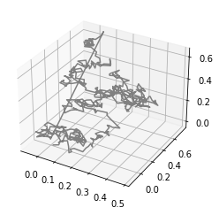

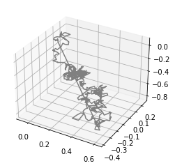

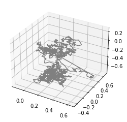

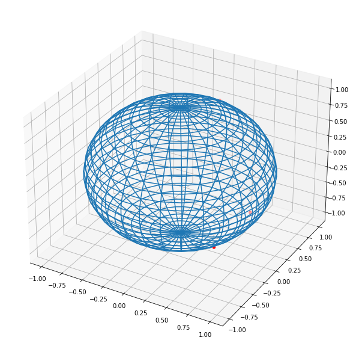

```python
w=np.array((0,0,0)); t=1; n=2000; N=3;
exit_times=np.array([simulate_exit_time(w,n,t) for k in range(0,N)]);

u = np.linspace(0,np.pi,30);
v = np.linspace(0,2*np.pi,30);

x = np.outer(np.sin(u),np.sin(v));
y = np.outer(np.sin(u),np.cos(v));
z = np.outer(np.cos(u),np.ones_like(v));

fig=plt.figure();
ax=plt.axes(projection='3d');
fig.set_size_inches(18.5, 10.5);
ax.plot_wireframe(x,y,z);
ax.scatter(exit_times[:,0],exit_times[:,1],exit_times[:,2],c='r');
plt.show();
```

```python
def check_exit(w):
    if np.linalg.norm(w) >=1:
        return True;
    return False;

def simulate_exit_time(w,n,t):
    h=np.sqrt(t/n);
    exit=False;
    x=w.copy();
    while not exit:
        U1=np.random.uniform(0,1,3);
        U2=np.random.uniform(0,1,3);
        y=np.sqrt(-2*np.log(U1))*np.cos(2*np.pi*U2);
        x=x+h*y
        exit=check_exit(x);
    return x;
```

```python
from scipy.stats import multivariate_normal
from mpl_toolkits.mplot3d import Axes3D
```

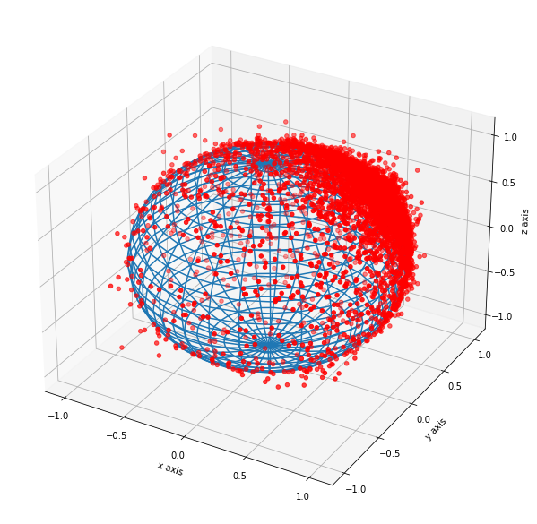

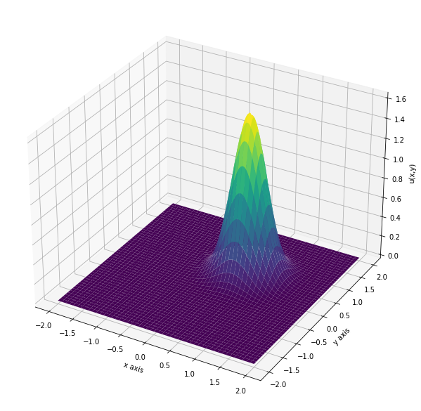

```
Mean: [0.49990773 0.49972163]
Convariance matrix: [[ 0.09907344 -0.00121611]
 [-0.00121611  0.09705651]]
Elapsed time: 6.03125 seconds
```

```python
t1_start=process_time();
w=np.array((0.5,0.5,0.5)); t=1; n=2000;
exit_times=np.array([simulate_exit_time(w,n,t) for k in range(0,10000)]);

u=np.linspace(0,np.pi,30);
v=np.linspace(0,2*np.pi,30);

x=np.outer(np.sin(u),np.sin(v));
y=np.outer(np.sin(u),np.cos(v));
z=np.outer(np.cos(u),np.ones_like(v));

fig=plt.figure();
ax=plt.axes(projection='3d');
fig.set_size_inches(18.5, 10.5);
ax.plot_wireframe(x,y,z);
ax.scatter(exit_times[:,0],exit_times[:,1],exit_times[:,2],c='r');
ax.set_xlabel('x axis');
ax.set_ylabel('y axis');
ax.set_zlabel('z axis');
plt.show();

X=np.stack((exit_times[:,0],exit_times[:,1]),axis=0);
covariance=np.cov(X);
mean=np.array([np.mean((exit_times[:,0])),np.mean((exit_times[:,1]))]);

x=np.linspace(-2,2,500); y=np.linspace(-2,2,500);
X,Y=np.meshgrid(x,y);
position=np.empty(X.shape+(2,));
position[:,:,0]=X; position[:,:,1]=Y;
rv=multivariate_normal(mean.T,covariance);

fig = plt.figure();
ax = fig.gca(projection='3d');
fig.set_size_inches(18.5, 10.5);
ax.plot_surface(X,Y,rv.pdf(position),cmap='viridis',linewidth=0);
ax.set_xlabel('x axis');
ax.set_ylabel('y axis');
ax.set_zlabel('u(x,y)');
plt.show();

t1_stop=process_time();
time=t1_stop-t1_start;
print("Mean: " + str(mean.T));
print("Convariance matrix: " + str(covariance));
print("Elapsed time: " + str(time) + " seconds");
```

As anticipated the estimated parameter $u(x,y)$ improved significantly in accuracy with the inclusion of a third-dimension; this statistical phenomenon can be explaid by the Strong Law of Large Numbers [[12](https://en.wikipedia.org/wiki/Law_of_large_numbers),[13](https://www.math.ucdavis.edu/~tracy/courses/math135A/UsefullCourseMaterial/lawLargeNo.pdf)], as stated in the law,

$$\bar{Y}=\frac{1}{n} \sum_{i=1}^{n} X_{i} \to \mu \text{ as } n \to \infty$$

and,

$$\text{Var}\big(\bar{Y}\big)=\text{Var}\big(\frac{1}{n}\big(X_{1}+\cdots+X_{n}\big)\big)=\frac{1}{n^{2}}\text{Var}\big(X_{1}+\cdots+X_{n}\big)=\frac{n\sigma^{2}}{n^{2}}=\frac{\sigma^{2}}{n}$$,

given $X_{1},\ldots, X_{n}$ were independent and identically distributed random variables with a population mean $\mu$ and population variance $sigma^{2}$. Peeling back, this subsequentially means our estimate parameter for the test function $u(x)$ will continuously improve with an increase in partitions of the time scale, `n`, or an increase in the number of Brownian motions path generated, or the addition of an additional dimension. This schema improve in computational efficiency and accuracy with an increase in the increase of sampling and dimension complexity of the problem itself; which is a profound and useful feature of this schema. To ground this assertion, one should note that our two-dimensional random walk algorithm took 13.28125 seconds to be computed, while the three dimensional random walk algorithm took half the time, 6.03125 seconds - which is a substantial quantity of computational savings, and this is what contributes to this schema interests and effect.  
The Walk-on-Sphere algorithm is an random walk algorithm itself,though it incorporate a computational saving technique known as sphere walking, which allows the algorithm to jump across its Brownian motion path without explicitly generating by superimposing a cirle in two-dimension, sphere in three-dimension, or a hyper-dimensioned sphere in n-dimensions greater than three, to jump from the first sampled of the Brownian motion path to the boundary condition, $\partial D$. Though this reduction in computational complexity does come without a cost, the reduction in the Brownian motion path's capacity to wonder results in an increase in the estimate parameter variance, which is not desire by the least, but is a price to be paid; nevertheless we will further elaborate about this matter in the coming section.  
To modify two-dimensioned random walk algorithm to a two-dimensioned WoS algorithm, we only needed to include, `x=x+np.random.uniform(-1,1,2)*(1-np.linalg.norm(x));`, which performs the sphere walk that generates the computational saving. In addition, as the sphere walk might make the Brownian motion path land on the boundary, $\partial D$, or pass it, and need to include an additional boundary check function, e.g., `exit=check_exit(x);`, which could test for this event.

```python
def check_exit(w):
    if np.linalg.norm(w) >=1:
        return True;
    return False;

def simulate_exit_time(w,n,t):
    h=np.sqrt(t/n);
    exit=False;
    x=w.copy();
    i=0; temp=0;
    while not exit:
        x=x+np.random.uniform(-1,1,2)*(1-np.linalg.norm(x));
        exit=check_exit(x);
        U1=np.random.uniform(0,1,2);
        U2=np.random.uniform(0,1,2);
        y=np.sqrt(-2*np.log(U1))*np.cos(2*np.pi*U2);
        x=x+h*y;
        exit=check_exit(x);
        if exit==False:
            r=1-np.linalg.norm(x);
            circle1=plt.Circle(x,radius=r,fill=False);
            plt.gcf().gca().add_artist(circle1);
            plt.axis([-1.2, 1.2, -1.2, 1.2]);
        if np.linalg.norm(temp)!=0:
            x_val=[temp[0],x[0]]; y_val=[temp[1],x[1]];
            plt.plot(x_val,y_val);
        plt.text(x[0],x[1],'x'+str(i));
        i=i+1;
        temp=x;
    return x;
```

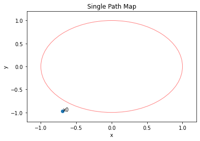

```python
w=np.array((0,0)); t=1; n=8;
exit_times=np.array([simulate_exit_time(w,n,t) for k in range(0,1)]);

circle1=plt.Circle((0,0),1,color='r', fill=False, alpha=.5);
plt.gcf().gca().add_artist(circle1);
plt.axis([-1.2, 1.2, -1.2, 1.2]);
plt.scatter(exit_times[:,0],exit_times[:,1]);
plt.title("Single Path Map");
plt.xlabel("x");
plt.ylabel("y");
plt.show();
```

Yet again this result is not quite impressive, but reflects that the algorithm functions as anticipated. Nevertheless we tested this algorithm more rigorously in this coming simulation; as we set the partition number to `n=2000` and set to number of Brownian motion paths to be generated to be ten-thousand.

```python
def check_exit(w):
    if np.linalg.norm(w) >=1:
        return True;
    return False;

def simulate_exit_time(w,n,t):
    h=np.sqrt(t/n);
    exit=False;
    x=w.copy();
    while not exit:
        x=x+np.random.uniform(-1,1,2)*(1-np.linalg.norm(x));
        exit=check_exit(x);
        U1=np.random.uniform(0,1,2);
        U2=np.random.uniform(0,1,2);
        y=np.sqrt(-3*np.log(U1))*np.cos(2*np.pi*U2);
        x=x+h*y;
        exit=check_exit(x);
    return x;
```

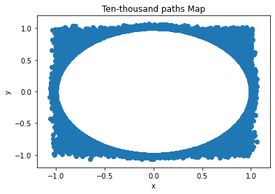

```
Elapsed time: 0.0 seconds
```

```python
t1_start=process_time();
w=np.array((0,0)); t=1; n=2000;
exit_times=np.array([simulate_exit_time(w,n,t) for k in range(0,10000)]);

circle1=plt.Circle((0,0),1,color='r', fill=False, alpha=.5);
plt.gcf().gca().add_artist(circle1);
plt.axis([-1.2, 1.2, -1.2, 1.2]);
plt.scatter(exit_times[:,0],exit_times[:,1]);
plt.title("Ten-thousand paths Map");
plt.xlabel("x");
plt.ylabel("y");
plt.show();
t1_start=process_time();

t1_stop=process_time();
time=t1_stop-t1_start
print("Elapsed time: " + str(time) + " seconds");
```

```
The value u(v) = 0.5000000000000001
The value of Exp(f(Exit))=0.4750938576421539
Elapsed time: 0.46875 seconds
```

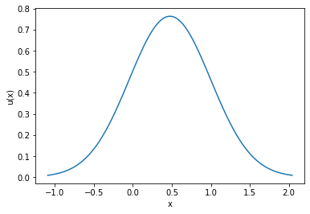

```python
t1_start=process_time();
w=np.array((0.5,0.5)); t=1; n=2000; n_trials=10000;
u=lambda x:np.linalg.norm(x,2)*np.cos(np.arctan2(x[0],x[1]))
f=lambda x:np.cos(np.arctan2(x[0],x[1]));

def get_exp_f_exit(starting, n_trials):
    temp=[f(simulate_exit_time(w,n,t)) for k in range(0,n_trials)];
    mean=np.mean(temp);
    std=np.std(temp);
    return mean,std;

[exp_f_exit,std]=get_exp_f_exit(w,n); # Expected value of f(Exit(x,d))
print('The value u(v) = %s\nThe value of Exp(f(Exit))=%s' %(u(w),exp_f_exit));
t1_stop=process_time();
time=t1_stop-t1_start
print("Elapsed time: " + str(time) + " seconds");

X=np.linspace(exp_f_exit-3*std,exp_f_exit+3*std,100);
plt.plot(X,stats.norm.pdf(X,exp_f_exit,std));
plt.xlabel('x');
plt.ylabel("u(x)");
plt.show();
```

But to actually computate the estimate parameter for $u(x)$, the WoS algorithm is slowed now significantly due to the increase in computational cost from calculating the expected value of the exit points, $\phi(y)$. Subsequentially it took 0.46875 seconds for WoS to be executed, which still means it is at least 25 times faster then a unmodified random walk algorithm.  
Though this algorithm's speed comes with a price, and we subsequentially illustrated this price in the following experiment. Yet again, we created a nested for loop to iterate over a list that contained the number of partitions to the time scale for each sample, we ran each `n` for ten trails.

```python
def get_exp_f_exit(starting, n_trials):
    temp=[simulate_exit_time(w,n,t) for k in range(0,n_trials)];
    mean=np.mean(temp);
    std=np.std(temp);
    return mean,std;

N=[20,50,100,1000];
x=np.zeros((5,10));

for i in range(len(N)):
    for j in range(10):
        w=np.array((0.5,0.5)); t=1; n=N[i]; n_trials=10000;
        [exp_f_exit,std]=get_exp_f_exit(w,n);
        x[i,j]=exp_f_exit;
    average=np.mean(x[i,:]);
    print("Pratitions: n=" + str(N[i]));
    print("u(x) for each number of partitions:")
    print(x[i,:])
    print(" ")
    print("Mean: " + str(np.mean(x[i,:])) + "  " + "Standard Deviation: " + str(np.std(x[i,:])));
    print("Confidence Interval: " +
          str(stats.t.interval(alpha=0.95, df=10-1, loc=average, scale=stats.sem(x[i,:]))));
    print(" ")
```

```
Pratitions: n=20
u(x) for each number of partitions:
[0.60796104 0.7056157  0.44806286 0.61544098 0.47900867 0.59362768
 0.5134996  0.34013929 0.32881127 0.61386683]

Mean: 0.524603393046668  Standard Deviation: 0.11879390779398587
Confidence Interval: (0.43502656324461536, 0.6141802228487208)

Pratitions: n=50
u(x) for each number of partitions:
[0.44170776 0.59827886 0.44136644 0.4913548  0.46087338 0.49730058
 0.48823907 0.52458649 0.38326813 0.50991511]

Mean: 0.48368906108486  Standard Deviation: 0.0546941679674221
Confidence Interval: (0.4424467931423057, 0.5249313290274142)

Pratitions: n=100
u(x) for each number of partitions:
[0.54564882 0.58283099 0.52117874 0.43085013 0.50907741 0.53401052
 0.49264159 0.53839612 0.56332669 0.47471964]

Mean: 0.5192680642400235  Standard Deviation: 0.042283963552511725
Confidence Interval: (0.4873837405668923, 0.5511523879131546)

Pratitions: n=1000
u(x) for each number of partitions:
[0.50337984 0.49493453 0.53223419 0.51156111 0.50662153 0.50806866
 0.49199076 0.51542369 0.51413768 0.48439092]

Mean: 0.5062742907533718  Standard Deviation: 0.012925248475583588
Confidence Interval: (0.496527976280289, 0.5160206052264547)
```

```python
def get_exp_f_exit(starting, n_trials):
    temp=[simulate_exit_time(w,n,t) for k in range(0,n_trials)];
    mean=np.mean(temp);
    std=np.std(temp);
    return mean,std;

N=[20,50,100,1000];
x=np.zeros((5,10));

for i in range(len(N)):
    for j in range(10):
        w=np.array((0.5,0.5)); t=1; n=2000; n_trials=N[i];
        [exp_f_exit,std]=get_exp_f_exit(w,n);
        x[i,j]=exp_f_exit;
    average=np.mean(x[i,:]);
    print("Number of Brownian Motion paths: n=" + str(N[i]));
    print("u(x) for each number of partitions:")
    print(x[i,:])
    print(" ")
    print("Mean: " + str(np.mean(x[i,:])) + "  " + "Standard Deviation: " + str(np.std(x[i,:])));
    print("Confidence Interval: " +
          str(stats.t.interval(alpha=0.95, df=10-1, loc=average, scale=stats.sem(x[i,:]))));
    print(" ")
```

```
Number of Brownian Motion paths: n=20
u(x) for each number of partitions:
[0.49689929 0.50626363 0.48291575 0.49370791 0.49784671 0.50638471
 0.49842884 0.50045169 0.50048015 0.50629054]

Mean: 0.49896692143088306  Standard Deviation: 0.006763964865807467
Confidence Interval: (0.4938665375743115, 0.5040673052874547)

Number of Brownian Motion paths: n=50
u(x) for each number of partitions:
[0.49562041 0.49897448 0.48533481 0.49179524 0.51034202 0.49997888
 0.49509138 0.49618547 0.50166653 0.51428331]

Mean: 0.49892725297939106  Standard Deviation: 0.008021870916099575
Confidence Interval: (0.49287834206224496, 0.5049761638965371)

Number of Brownian Motion paths: n=100
u(x) for each number of partitions:
[0.50002721 0.5132772  0.49540537 0.50290886 0.50378637 0.51584573
 0.48406754 0.50563839 0.51018031 0.47964102]

Mean: 0.5010777991183216  Standard Deviation: 0.01124022129847028
Confidence Interval: (0.4926020834112788, 0.5095535148253644)

Number of Brownian Motion paths: n=1000
u(x) for each number of partitions:
[0.5020987  0.48581531 0.51064625 0.50646161 0.50097775 0.49536688
 0.49872088 0.50226222 0.50124524 0.51164271]

Mean: 0.5015237553378354  Standard Deviation: 0.00709764508268056
Confidence Interval: (0.49617175911704237, 0.5068757515586285)
```

Though if the time scale mesh is given to be fine, i.e., `n=2000`, the fewer Brownian motion paths needed to be generated to attain a substantially lower variance when compared to a less fine time scale mesh and more Brownian motion path generated. Overall the finer time scale mesh attains a tigher confidence interval, compared to the opposite paradigm.  
An additional price of the WoS algorithm is that, the algorithm sphere walk is domain boundary sensitive, as each different type of boundary condition require a different size sphere to be superimposed over the Brownian motion path to sphere hop. In case of the unit circle, the optimal radius of the cirle is `0.90-np.linalg.norm(x)` and not `1-np.linalg.norm(x)`, as the former approach hops the Brownian motion path closer to the boundary condition, $\partial D$, when the path reachs ourside the domain $D$.

```python
def check_exit(w):
    if np.linalg.norm(w)>=1:
        return True;
    return False;

def simulate_exit_time(w,n,t):
    h=np.sqrt(t/n);
    exit=False;
    x=w.copy();
    while not exit:
        x=x+np.random.uniform(-1,1,2)*(0.90-np.linalg.norm(x));
        exit=check_exit(x);
        U1=np.random.uniform(0,1,2);
        U2=np.random.uniform(0,1,2);
        y=np.sqrt(-3*np.log(U1))*np.cos(2*np.pi*U2);
        x=x+h*y;
        exit=check_exit(x);
    return x;
```

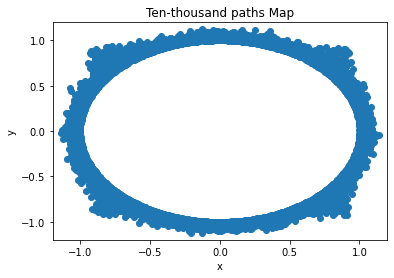

```
Elapsed time: 0.0 seconds
```

```python
t1_start=process_time();
w=np.array((0,0)); t=1; n=2000;
exit_times=np.array([simulate_exit_time(w,n,t) for k in range(0,10000)]);

circle1=plt.Circle((0,0),1,color='r', fill=False, alpha=.5);
plt.gcf().gca().add_artist(circle1);
plt.axis([-1.2, 1.2, -1.2, 1.2]);
plt.scatter(exit_times[:,0],exit_times[:,1]);
plt.title("Ten-thousand paths Map");
plt.xlabel("x");
plt.ylabel("y");
plt.show();
t1_start=process_time();

t1_stop=process_time();
time=t1_stop-t1_start
print("Elapsed time: " + str(time) + " seconds");
```

```
The value u(v) = 0.5000000000000001
The value of Exp(f(Exit))=0.4853080367554272
Elapsed time: 1.578125 seconds
```

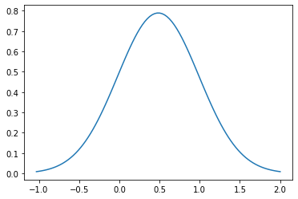

```python
t1_start=process_time();
w=np.array((0.5,0.5)); t=1; n=2000; n_trials=10000;
u=lambda x:np.linalg.norm(x,2)*np.cos(np.arctan2(x[0],x[1]))
f=lambda x:np.cos(np.arctan2(x[0],x[1]));

def get_exp_f_exit(starting, n_trials):
    temp=[f(simulate_exit_time(w,n,t)) for k in range(0,n_trials)];
    mean=np.mean(temp);
    std=np.std(temp);
    return mean,std;

[exp_f_exit,std]=get_exp_f_exit(w,n); # Expected value of f(Exit(x,d))
print('The value u(v) = %s\nThe value of Exp(f(Exit))=%s' %(u(w),exp_f_exit));
t1_stop=process_time();
time=t1_stop-t1_start
print("Elapsed time: " + str(time) + " seconds");

X=np.linspace(exp_f_exit-3*std,exp_f_exit+3*std,100);
plt.plot(X,stats.norm.pdf(X,exp_f_exit,std));
plt.show();
```

There was a computational expense increased due to the increase wonder of each Brownian motion path. Though on the surface level it does not seem to improve the the estimate parameter accuracy. Immediately were able to experiment to determine the true nature of this modificaton, through the experimentation of different number of partitions with ten-thousands Brownian motion path generated.

```python
def get_exp_f_exit(starting, n_trials):
    temp=[simulate_exit_time(w,n,t) for k in range(0,n_trials)];
    mean=np.mean(temp);
    std=np.std(temp);
    return mean,std;

N=[20,50,100,1000];
x=np.zeros((5,10));

for i in range(len(N)):
    for j in range(10):
        w=np.array((0.5,0.5)); t=1; n=N[i]; n_trials=10000;
        [exp_f_exit,std]=get_exp_f_exit(w,n);
        x[i,j]=exp_f_exit;
    average=np.mean(x[i,:]);
    print("Pratitions: n=" + str(N[i]));
    print("u(x) for each number of partitions:")
    print(x[i,:])
    print(" ")
    print("Mean: " + str(np.mean(x[i,:])) + "  " + "Standard Deviation: " + str(np.std(x[i,:])));
    print("Confidence Interval: " +
          str(stats.t.interval(alpha=0.95, df=10-1, loc=average, scale=stats.sem(x[i,:]))));
    print(" ")
```

```
Pratitions: n=20
u(x) for each number of partitions:
[0.54378924 0.55370332 0.56972244 0.44460293 0.50846027 0.61336456
 0.51468299 0.41302072 0.45406831 0.46521431]

Mean: 0.5080629092411222  Standard Deviation: 0.06008772189902315
Confidence Interval: (0.4627536190789009, 0.5533721994033435)

Pratitions: n=50
u(x) for each number of partitions:
[0.52665544 0.53846206 0.42667981 0.58989596 0.51137699 0.50116118
 0.4994684  0.42299486 0.50285653 0.48866534]

Mean: 0.5008216567295037  Standard Deviation: 0.04673084282118077
Confidence Interval: (0.4655841531265512, 0.5360591603324563)

Pratitions: n=100
u(x) for each number of partitions:
[0.51062661 0.55128694 0.48202117 0.50129043 0.48707086 0.5065449
 0.5401734  0.47642067 0.49339826 0.49643152]

Mean: 0.5045264760723107  Standard Deviation: 0.02302062409874626
Confidence Interval: (0.4871677195070618, 0.5218852326375596)

Pratitions: n=1000
u(x) for each number of partitions:
[0.50457662 0.49111654 0.50152331 0.51793914 0.47226869 0.50833104
 0.51356948 0.51751284 0.52648644 0.49625299]

Mean: 0.5049577079720862  Standard Deviation: 0.014909860309152695
Confidence Interval: (0.4937148922074804, 0.516200523736692)
```

```python
def get_exp_f_exit(starting, n_trials):
    temp=[simulate_exit_time(w,n,t) for k in range(0,n_trials)];
    mean=np.mean(temp);
    std=np.std(temp);
    return mean,std;

N=[20,50,100,1000];
x=np.zeros((5,10));

for i in range(len(N)):
    for j in range(10):
        w=np.array((0.5,0.5)); t=1; n=2000; n_trials=N[i];
        [exp_f_exit,std]=get_exp_f_exit(w,n);
        x[i,j]=exp_f_exit;
    average=np.mean(x[i,:]);
    print("Number of Brownian motion paths: n=" + str(N[i]));
    print("u(x) for each number of partitions:")
    print(x[i,:])
    print(" ")
    print("Mean: " + str(np.mean(x[i,:])) + "  " + "Standard Deviation: " + str(np.std(x[i,:])));
    print("Confidence Interval: " +
          str(stats.t.interval(alpha=0.95, df=10-1, loc=average, scale=stats.sem(x[i,:]))));
    print(" ")
```

```
Number of Brownian motion paths: n=20
u(x) for each number of partitions:
[0.51029718 0.50614139 0.50449623 0.50269223 0.48942595 0.49793059
 0.51125206 0.50186247 0.49768094 0.50691276]

Mean: 0.5028691794574959  Standard Deviation: 0.0062307772467293234
Confidence Interval: (0.4981708469981184, 0.5075675119168733)

Number of Brownian motion paths: n=50
u(x) for each number of partitions:
[0.5021013  0.50757713 0.49219975 0.51679515 0.49472622 0.48504598
 0.50078998 0.4870636  0.49735946 0.50100282]

Mean: 0.49846613878902046  Standard Deviation: 0.008992274881761977
Confidence Interval: (0.4916854924446492, 0.5052467851333917)

Number of Brownian motion paths: n=100
u(x) for each number of partitions:
[0.503171   0.50291864 0.49806431 0.50428716 0.48580501 0.50635932
 0.49297823 0.50255028 0.49273044 0.4960246 ]

Mean: 0.4984888966534903  Standard Deviation: 0.006198905171090228
Confidence Interval: (0.49381459740884565, 0.503163195898135)

Number of Brownian motion paths: n=1000
u(x) for each number of partitions:
[0.49921481 0.51443222 0.5136268  0.49104008 0.5019019  0.49466329
 0.50811942 0.48622713 0.51143108 0.50789772]

Mean: 0.5028554448595384  Standard Deviation: 0.009349320893785372
Confidence Interval: (0.4958055671173248, 0.5099053226017519)
```

```python
def check_exit(w):
    if np.linalg.norm(w) >=1:
        return True;
    return False;

def simulate_exit_time(w,n,t):
    h=np.sqrt(t/n);
    exit=False;
    x=w.copy();
    while not exit:
        x=x+np.random.uniform(-1,1,3)*(1-np.linalg.norm(x));
        exit=check_exit(x);
        U1=np.random.uniform(0,1,3);
        U2=np.random.uniform(0,1,3);
        y=np.sqrt(-2*np.log(U1))*np.cos(2*np.pi*U2);
        x=x+h*y
        exit=check_exit(x);
    return x;
```

Partition number was set to `n=2000` with ten-thousand Brownian motion path generated.

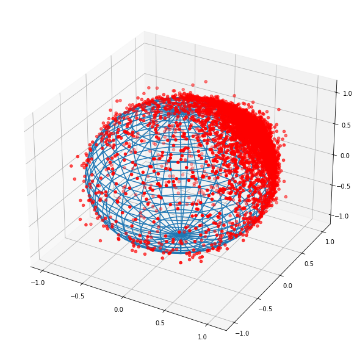

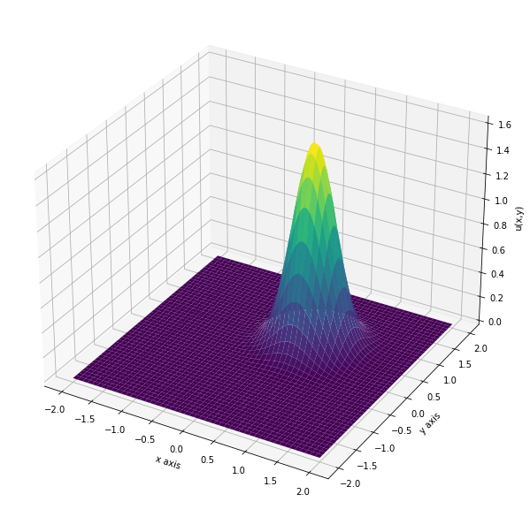

```
Mean: [0.50125845 0.5000549 ]
Convariance matrix: [[0.0968253  0.00165539]
 [0.00165539 0.09956437]]
Elapsed time: 7.0625 seconds
```

```python
t1_start=process_time();
w=np.array((0.5,0.5,0.5)); t=1; n=2000;
exit_times=np.array([simulate_exit_time(w,n,t) for k in range(0,10000)]);

u=np.linspace(0,np.pi,30);
v=np.linspace(0,2*np.pi,30);

x=np.outer(np.sin(u),np.sin(v));
y=np.outer(np.sin(u),np.cos(v));
z=np.outer(np.cos(u),np.ones_like(v));

fig=plt.figure();
ax=plt.axes(projection='3d');
fig.set_size_inches(18.5, 10.5);
ax.plot_wireframe(x,y,z);
ax.scatter(exit_times[:,0],exit_times[:,1],exit_times[:,2],c='r');
plt.show();

X=np.stack((exit_times[:,0],exit_times[:,1]),axis=0);
covariance=np.cov(X);
mean=np.array([np.mean((exit_times[:,0])),np.mean((exit_times[:,1]))]);

x=np.linspace(-2,2,500); y=np.linspace(-2,2,500);
X,Y=np.meshgrid(x,y);
position=np.empty(X.shape+(2,));
position[:,:,0]=X; position[:,:,1]=Y;
rv=multivariate_normal(mean.T,covariance);

fig = plt.figure();
ax = fig.gca(projection='3d');
fig.set_size_inches(18.5, 10.5);
ax.plot_surface(X,Y,rv.pdf(position),cmap='viridis',linewidth=0);
ax.set_xlabel('x axis');
ax.set_ylabel('y axis');
ax.set_zlabel('u(x,y)');
plt.show();

t1_stop=process_time();
time=t1_stop-t1_start;
print("Mean: " + str(mean.T));
print("Convariance matrix: " + str(covariance));
print("Elapsed time: " + str(time) + " seconds");
```

Ding et al. (2022) [15] is the natural evolution of Yan et al. (2013) [0], the authors further developed their hybrid-algorithm, the Walk-on-Sphere (WoS) - Boundary Integral Equation (BIE) algorithm, which can approximate global solutions to a large variety of mixed type Boundary Value Problems (BVPs) of the Laplace equations. Though the mechination are far more developed in this paper Ding et al. (2022) [15],then in Yan et al. (2013) [0]. Example of the research efforts maturity is the flow-chart that pertain to the WoS-BIE algorithm, which details the various steps in the computation process. Lastly the numerical result from the WoS-BIE algorithm are quite fascinating, and quite worthy of review; overall Ding et al. (2022) [15] is well-created.

### References:

1. [0]: A Parallel Method for Solving Laplace Equations with Dirichlet Data Using Local Boundary Integral Equations and Random Walks. In SIAM Journal on Scientific Computing, vol. 35, pp. B868–B889, 2013.
2. [1]: Nikolai A. Simonov, Walk-on-spheres algorithm for solving third boundary value problem, Applied Mathematics Letters, Volume 64, 2017, Pages 156-161, ISSN 0893-9659, https://doi.org/10.1016/j.aml.2016.09.008.
3. [2]: Nikolai Simonov. Walk-on-Spheres Algorithm for Solving Boundary-Value Problems with Continuity Flux Conditions. In Monte Carlo and Quasi-Monte Carlo Methods 2006, Ed.: Keller, Alexander and Heinrich, Stefan and Niederreiter, Harald, Springer Berlin Heidelberg, pp. 633–643, 2008. https://doi.org/10.1007/978-3-540-74496-2_38
4. [3]: Rohan Sawhney and Keenan Crane. Monte Carlo Geometry Processing: A Grid-Free Approach to PDE-Based Methods on Volumetric Domains. In ACM Trans. Graph., vol. 39, 2020. [http://www.cs.cmu.edu/~kmcrane/Projects/MonteCarloGeometryProcessing/paper.pdf](http://www.cs.cmu.edu/~kmcrane/Projects/MonteCarloGeometryProcessing/paper.pdf  
   )
5. [4]: Rohan Sawhney.WoS Laplace 2D (Algorithm). 2020. http://www.cs.cmu.edu/~kmcrane/Projects/MonteCarloGeometryProcessing/WoSLaplace2D.cpp.html
6. [5]: Forrest Flesher. Stochastic Processes and The Feynman-Kac Theorem. https://scholar.harvard.edu/files/forrestgflesher/files/final_paper_final.pdf
7. [6]: Dirk P. Kroese, Thomas, Taimre, and Zdravko I., Botev. Handbook of Monte Carlo methods / Dirk P. Kroese, Thomas Taimre, Zdravko I. Botev. Wiley New Jersey , ISBN: 9780470177938 0470177934 , 2011. https://onlinelibrary.wiley.com/doi/book/10.1002/9781118014967
8. [7]: D.P. Kroese, T. Taimre, Z.I. Botev (2011). Handbook of Monte Carlo Methods, Wiley Series in Probability and Statistics, John Wiley and Sons, New York. Textbook website: https://onlinelibrary.wiley.com/doi/book/10.1002/9781118014967
9. [8]: Dirk P. Kroese, Thomas Taimre, Zdravko I. Botev. Handbook of Monte Carlo Methods. John Wiley & Sons, Inc. ISBN: 9780470177938 , 28 February 2011. https://people.smp.uq.edu.au/DirkKroese/montecarlohandbook/
10. [9]: Wikipedia. Box-Muller transform. https://en.wikipedia.org/wiki/Box%E2%80%93Muller_transform
11. [10]: Confidence Interval. http://www.stat.yale.edu/Courses/1997-98/101/confint.htm
12. [11]: Danielle Navarro. Book: Learning Statistics with R - A tutorial for Psychology Students and other Beginners (Navarro). 10.4: Estimating Population Parameters University of New South Wales. 2022. https://stats.libretexts.org/Bookshelves/Applied_Statistics/Book%3A_Learning_Statistics_with_R_-_A_tutorial_for_Psychology_Students_and_other_Beginners_(Navarro)/10%3A_Estimating_Unknown_Quantities_from_a_Sample/10.04%3A_Estimating_Population_Parameters
13. [12]: Wikipedia. Law of large numbers. https://en.wikipedia.org/wiki/Law_of_large_numbers
14. [13]: Craig A. Tracy. Laws of Large Numbers. Distinguished Professor, emeritus Department of Mathematics UC Davis. 2003. https://www.math.ucdavis.edu/~tracy/courses/math135A/UsefullCourseMaterial/
15. Cuiyang Ding, Changhao Yan, Xuan Zeng, and Wei Cai. A Parallel Iterative Probabilistic Method for Mixed Problems of Laplace Equations with the Feynman--Kac Formula of Killed Brownian Motions. In SIAM Journal on Scientific Computing, vol. 44, pp. A3413–A3435, 2022.